# Final_project slides

```python
import sys
import numpy as np
import pandas as pd
import matplotlib.pyplot as plt
import seaborn as sns
from scipy import stats
import warnings
warnings.filterwarnings('ignore')

df = pd.read_csv('datasets/AB_NYC_2019.csv')
```

#### Link to dataset: https://www.kaggle.com/dgomonov/new-york-city-airbnb-open-data

### Goal:

#### To out where in New York City is the best place to rent an Airbnb and what type of room to get

```python
df.dropna()
```

|  | id | name | host_id | host_name | neighbourhood_group | neighbourhood | latitude | longitude | room_type | price | minimum_nights | number_of_reviews | last_review | reviews_per_month | calculated_host_listings_count | availability_365 |
| --- | --- | --- | --- | --- | --- | --- | --- | --- | --- | --- | --- | --- | --- | --- | --- | --- |
| 0 | 2539 | Clean & quiet apt home by the park | 2787 | John | Brooklyn | Kensington | 40.64749 | -73.97237 | Private room | 149 | 1 | 9 | 2018-10-19 | 0.21 | 6 | 365 |
| 1 | 2595 | Skylit Midtown Castle | 2845 | Jennifer | Manhattan | Midtown | 40.75362 | -73.98377 | Entire home/apt | 225 | 1 | 45 | 2019-05-21 | 0.38 | 2 | 355 |
| 3 | 3831 | Cozy Entire Floor of Brownstone | 4869 | LisaRoxanne | Brooklyn | Clinton Hill | 40.68514 | -73.95976 | Entire home/apt | 89 | 1 | 270 | 2019-07-05 | 4.64 | 1 | 194 |
| 4 | 5022 | Entire Apt: Spacious Studio/Loft by central park | 7192 | Laura | Manhattan | East Harlem | 40.79851 | -73.94399 | Entire home/apt | 80 | 10 | 9 | 2018-11-19 | 0.10 | 1 | 0 |
| 5 | 5099 | Large Cozy 1 BR Apartment In Midtown East | 7322 | Chris | Manhattan | Murray Hill | 40.74767 | -73.97500 | Entire home/apt | 200 | 3 | 74 | 2019-06-22 | 0.59 | 1 | 129 |
| 6 | 5121 | BlissArtsSpace! | 7356 | Garon | Brooklyn | Bedford-Stuyvesant | 40.68688 | -73.95596 | Private room | 60 | 45 | 49 | 2017-10-05 | 0.40 | 1 | 0 |
| 7 | 5178 | Large Furnished Room Near B'way | 8967 | Shunichi | Manhattan | Hell's Kitchen | 40.76489 | -73.98493 | Private room | 79 | 2 | 430 | 2019-06-24 | 3.47 | 1 | 220 |
| 8 | 5203 | Cozy Clean Guest Room - Family Apt | 7490 | MaryEllen | Manhattan | Upper West Side | 40.80178 | -73.96723 | Private room | 79 | 2 | 118 | 2017-07-21 | 0.99 | 1 | 0 |
| 9 | 5238 | Cute & Cozy Lower East Side 1 bdrm | 7549 | Ben | Manhattan | Chinatown | 40.71344 | -73.99037 | Entire home/apt | 150 | 1 | 160 | 2019-06-09 | 1.33 | 4 | 188 |
| 10 | 5295 | Beautiful 1br on Upper West Side | 7702 | Lena | Manhattan | Upper West Side | 40.80316 | -73.96545 | Entire home/apt | 135 | 5 | 53 | 2019-06-22 | 0.43 | 1 | 6 |
| 11 | 5441 | Central Manhattan/near Broadway | 7989 | Kate | Manhattan | Hell's Kitchen | 40.76076 | -73.98867 | Private room | 85 | 2 | 188 | 2019-06-23 | 1.50 | 1 | 39 |
| 12 | 5803 | Lovely Room 1, Garden, Best Area, Legal rental | 9744 | Laurie | Brooklyn | South Slope | 40.66829 | -73.98779 | Private room | 89 | 4 | 167 | 2019-06-24 | 1.34 | 3 | 314 |
| 13 | 6021 | Wonderful Guest Bedroom in Manhattan for SINGLES | 11528 | Claudio | Manhattan | Upper West Side | 40.79826 | -73.96113 | Private room | 85 | 2 | 113 | 2019-07-05 | 0.91 | 1 | 333 |
| 14 | 6090 | West Village Nest - Superhost | 11975 | Alina | Manhattan | West Village | 40.73530 | -74.00525 | Entire home/apt | 120 | 90 | 27 | 2018-10-31 | 0.22 | 1 | 0 |
| 15 | 6848 | Only 2 stops to Manhattan studio | 15991 | Allen & Irina | Brooklyn | Williamsburg | 40.70837 | -73.95352 | Entire home/apt | 140 | 2 | 148 | 2019-06-29 | 1.20 | 1 | 46 |
| 16 | 7097 | Perfect for Your Parents + Garden | 17571 | Jane | Brooklyn | Fort Greene | 40.69169 | -73.97185 | Entire home/apt | 215 | 2 | 198 | 2019-06-28 | 1.72 | 1 | 321 |
| 17 | 7322 | Chelsea Perfect | 18946 | Doti | Manhattan | Chelsea | 40.74192 | -73.99501 | Private room | 140 | 1 | 260 | 2019-07-01 | 2.12 | 1 | 12 |
| 18 | 7726 | Hip Historic Brownstone Apartment with Backyard | 20950 | Adam And Charity | Brooklyn | Crown Heights | 40.67592 | -73.94694 | Entire home/apt | 99 | 3 | 53 | 2019-06-22 | 4.44 | 1 | 21 |
| 20 | 7801 | Sweet and Spacious Brooklyn Loft | 21207 | Chaya | Brooklyn | Williamsburg | 40.71842 | -73.95718 | Entire home/apt | 299 | 3 | 9 | 2011-12-28 | 0.07 | 1 | 0 |
| 21 | 8024 | CBG CtyBGd HelpsHaiti rm#1:1-4 | 22486 | Lisel | Brooklyn | Park Slope | 40.68069 | -73.97706 | Private room | 130 | 2 | 130 | 2019-07-01 | 1.09 | 6 | 347 |
| 22 | 8025 | CBG Helps Haiti Room#2.5 | 22486 | Lisel | Brooklyn | Park Slope | 40.67989 | -73.97798 | Private room | 80 | 1 | 39 | 2019-01-01 | 0.37 | 6 | 364 |
| 23 | 8110 | CBG Helps Haiti Rm #2 | 22486 | Lisel | Brooklyn | Park Slope | 40.68001 | -73.97865 | Private room | 110 | 2 | 71 | 2019-07-02 | 0.61 | 6 | 304 |
| 24 | 8490 | MAISON DES SIRENES1,bohemian apartment | 25183 | Nathalie | Brooklyn | Bedford-Stuyvesant | 40.68371 | -73.94028 | Entire home/apt | 120 | 2 | 88 | 2019-06-19 | 0.73 | 2 | 233 |
| 25 | 8505 | Sunny Bedroom Across Prospect Park | 25326 | Gregory | Brooklyn | Windsor Terrace | 40.65599 | -73.97519 | Private room | 60 | 1 | 19 | 2019-06-23 | 1.37 | 2 | 85 |
| 27 | 9357 | Midtown Pied-a-terre | 30193 | Tommi | Manhattan | Hell's Kitchen | 40.76715 | -73.98533 | Entire home/apt | 150 | 10 | 58 | 2017-08-13 | 0.49 | 1 | 75 |
| 28 | 9518 | SPACIOUS, LOVELY FURNISHED MANHATTAN BEDROOM | 31374 | Shon | Manhattan | Inwood | 40.86482 | -73.92106 | Private room | 44 | 3 | 108 | 2019-06-15 | 1.11 | 3 | 311 |
| 29 | 9657 | Modern 1 BR / NYC / EAST VILLAGE | 21904 | Dana | Manhattan | East Village | 40.72920 | -73.98542 | Entire home/apt | 180 | 14 | 29 | 2019-04-19 | 0.24 | 1 | 67 |
| 30 | 9668 | front room/double bed | 32294 | Ssameer Or Trip | Manhattan | Harlem | 40.82245 | -73.95104 | Private room | 50 | 3 | 242 | 2019-06-01 | 2.04 | 3 | 355 |
| 31 | 9704 | Spacious 1 bedroom in luxe building | 32045 | Teri | Manhattan | Harlem | 40.81305 | -73.95466 | Private room | 52 | 2 | 88 | 2019-06-14 | 1.42 | 1 | 255 |
| 32 | 9782 | Loft in Williamsburg Area w/ Roof | 32169 | Andrea | Brooklyn | Greenpoint | 40.72219 | -73.93762 | Private room | 55 | 4 | 197 | 2019-06-15 | 1.65 | 3 | 284 |
| ... | ... | ... | ... | ... | ... | ... | ... | ... | ... | ... | ... | ... | ... | ... | ... | ... |
| 48387 | 36233091 | 1 room in bushwick | 258998574 | Emily | Brooklyn | Bushwick | 40.70384 | -73.92232 | Private room | 40 | 2 | 1 | 2019-07-03 | 1.00 | 1 | 16 |
| 48391 | 36235150 | Sky View beautiful apt in Williamsburg New York | 208514239 | Melki | Brooklyn | Williamsburg | 40.71232 | -73.94220 | Entire home/apt | 170 | 1 | 1 | 2019-07-07 | 1.00 | 3 | 340 |
| 48392 | 36235154 | Top on Manhattan | 3850264 | Jason | Manhattan | Harlem | 40.80658 | -73.95736 | Private room | 138 | 3 | 1 | 2019-07-03 | 1.00 | 2 | 65 |
| 48394 | 36236013 | READY BED GO the goal is to make u feel at home | 256197494 | Emanuel | Brooklyn | Cypress Hills | 40.68042 | -73.88978 | Private room | 75 | 1 | 1 | 2019-07-05 | 1.00 | 1 | 82 |
| 48401 | 36237529 | Beautiful Cozy Room, 20mn to FREE ferry | 272557707 | Marouene | Staten Island | Rosebank | 40.60750 | -74.07979 | Private room | 65 | 1 | 1 | 2019-07-05 | 1.00 | 1 | 179 |
| 48404 | 36238485 | Chic Room in Williamsburg + Backyard +Washer D... | 22157126 | Ryan | Brooklyn | Williamsburg | 40.71773 | -73.94159 | Private room | 91 | 2 | 1 | 2019-07-04 | 1.00 | 1 | 344 |
| 48409 | 36241283 | Enjoy your friendly stay at my place | 267943725 | Lana | Brooklyn | Midwood | 40.62555 | -73.95724 | Private room | 50 | 1 | 1 | 2019-07-02 | 1.00 | 1 | 86 |
| 48410 | 36241782 | Classic Brooklyn Loft (East Williamsburg/Bushw... | 12091973 | Ap | Brooklyn | Williamsburg | 40.70518 | -73.93794 | Private room | 100 | 1 | 1 | 2019-07-06 | 1.00 | 1 | 1 |
| 48413 | 36242888 | Upper East Site Luxury 2 Bed rooms | 12579773 | Jean-Nicolas | Manhattan | Upper East Side | 40.76996 | -73.95117 | Private room | 220 | 4 | 1 | 2019-07-03 | 1.00 | 1 | 15 |
| 48453 | 36272851 | Private Bedroom in a Prewar Gramercy Building!* | 19962052 | Thikshan | Manhattan | Kips Bay | 40.73929 | -73.98183 | Private room | 135 | 2 | 1 | 2019-07-07 | 1.00 | 3 | 41 |
| 48454 | 36273046 | Elegant Spacious UES private room | 267839371 | Celine | Manhattan | Upper East Side | 40.77551 | -73.95404 | Private room | 120 | 1 | 1 | 2019-07-06 | 1.00 | 2 | 358 |
| 48457 | 36274037 | Cozy Wall Street Studio | 272816114 | Schmid | Manhattan | Financial District | 40.70583 | -74.01038 | Entire home/apt | 170 | 1 | 1 | 2019-07-06 | 1.00 | 1 | 323 |
| 48486 | 36280646 | Cable and wfi, L/G included. | 272872092 | Chris | Queens | Forest Hills | 40.73657 | -73.85088 | Entire home/apt | 16 | 9 | 1 | 2019-07-07 | 1.00 | 1 | 322 |
| 48524 | 36308600 | Cozy and Beautiful Park Slope One Bedroom | 74773867 | Kailey | Brooklyn | Park Slope | 40.67455 | -73.98477 | Entire home/apt | 150 | 1 | 1 | 2019-07-05 | 1.00 | 1 | 8 |
| 48526 | 36309284 | Private Room Near JFK, St John's Hospital, & B... | 234090781 | Phoenix | Queens | Bayswater | 40.60804 | -73.75829 | Private room | 45 | 3 | 1 | 2019-07-04 | 1.00 | 2 | 90 |
| 48532 | 36310268 | Full size room | 171482981 | Alejandro | Queens | Maspeth | 40.71327 | -73.90982 | Private room | 65 | 2 | 1 | 2019-07-06 | 1.00 | 1 | 21 |
| 48534 | 36310855 | Room 3: Cozy Room w Large Closet & Light Break... | 268394581 | Rehana | Brooklyn | Bedford-Stuyvesant | 40.68969 | -73.93285 | Private room | 68 | 1 | 1 | 2019-07-06 | 1.00 | 3 | 127 |
| 48576 | 36318560 | Luxury Sun-filled Private Room near Time Square | 52917571 | Linda Lou | Manhattan | Midtown | 40.75286 | -73.99297 | Private room | 120 | 2 | 1 | 2019-07-06 | 1.00 | 1 | 7 |
| 48601 | 36335990 | Sunny Studio steps from Wall Street | 269870940 | Farina | Manhattan | Financial District | 40.70603 | -74.01084 | Entire home/apt | 75 | 1 | 1 | 2019-07-03 | 1.00 | 1 | 181 |
| 48615 | 36344079 | The Little Castle in Astoria | 3867848 | Prince | Queens | Astoria | 40.76887 | -73.91128 | Private room | 150 | 1 | 1 | 2019-07-04 | 1.00 | 1 | 165 |
| 48634 | 36351128 | One bedroom without roomies, close to everything | 273361532 | David & Amy | Manhattan | Upper West Side | 40.80281 | -73.96550 | Entire home/apt | 110 | 3 | 2 | 2019-07-05 | 2.00 | 1 | 15 |
| 48636 | 36351543 | 2-MONTH SUBLEASE (WITH EARLY MOVE-IN) | 52984497 | Friday | Brooklyn | Bedford-Stuyvesant | 40.68914 | -73.92408 | Private room | 33 | 30 | 2 | 2019-07-06 | 2.00 | 1 | 87 |
| 48701 | 36390226 | Comfortable clean Bedstuy private room | 267932490 | Angela | Brooklyn | Bedford-Stuyvesant | 40.69551 | -73.93951 | Private room | 45 | 1 | 2 | 2019-07-08 | 2.00 | 1 | 14 |
| 48732 | 36411407 | Brand new 1 bedroom steps from Soho! | 33917435 | Mike | Manhattan | Lower East Side | 40.71825 | -73.99019 | Entire home/apt | 150 | 4 | 1 | 2019-07-06 | 1.00 | 1 | 13 |
| 48740 | 36413632 | Spacious 2BR in Beautiful Brooklyn Heights | 6608220 | Matt | Brooklyn | Brooklyn Heights | 40.69827 | -73.99649 | Entire home/apt | 550 | 3 | 1 | 2019-07-07 | 1.00 | 1 | 230 |
| 48782 | 36425863 | Lovely Privet Bedroom with Privet Restroom | 83554966 | Rusaa | Manhattan | Upper East Side | 40.78099 | -73.95366 | Private room | 129 | 1 | 1 | 2019-07-07 | 1.00 | 1 | 147 |
| 48790 | 36427429 | No.2 with queen size bed | 257683179 | H Ai | Queens | Flushing | 40.75104 | -73.81459 | Private room | 45 | 1 | 1 | 2019-07-07 | 1.00 | 6 | 339 |
| 48799 | 36438336 | Seas The Moment | 211644523 | Ben | Staten Island | Great Kills | 40.54179 | -74.14275 | Private room | 235 | 1 | 1 | 2019-07-07 | 1.00 | 1 | 87 |
| 48805 | 36442252 | 1B-1B apartment near by Metro | 273841667 | Blaine | Bronx | Mott Haven | 40.80787 | -73.92400 | Entire home/apt | 100 | 1 | 2 | 2019-07-07 | 2.00 | 1 | 40 |
| 48852 | 36455809 | Cozy Private Room in Bushwick, Brooklyn | 74162901 | Christine | Brooklyn | Bushwick | 40.69805 | -73.92801 | Private room | 30 | 1 | 1 | 2019-07-08 | 1.00 | 1 | 1 |

38821 rows × 16 columns

```python
df.head()
```

|  | id | name | host_id | host_name | neighbourhood_group | neighbourhood | latitude | longitude | room_type | price | minimum_nights | number_of_reviews | last_review | reviews_per_month | calculated_host_listings_count | availability_365 |
| --- | --- | --- | --- | --- | --- | --- | --- | --- | --- | --- | --- | --- | --- | --- | --- | --- |
| 0 | 2539 | Clean & quiet apt home by the park | 2787 | John | Brooklyn | Kensington | 40.64749 | -73.97237 | Private room | 149 | 1 | 9 | 2018-10-19 | 0.21 | 6 | 365 |
| 1 | 2595 | Skylit Midtown Castle | 2845 | Jennifer | Manhattan | Midtown | 40.75362 | -73.98377 | Entire home/apt | 225 | 1 | 45 | 2019-05-21 | 0.38 | 2 | 355 |
| 2 | 3647 | THE VILLAGE OF HARLEM....NEW YORK ! | 4632 | Elisabeth | Manhattan | Harlem | 40.80902 | -73.94190 | Private room | 150 | 3 | 0 | NaN | NaN | 1 | 365 |
| 3 | 3831 | Cozy Entire Floor of Brownstone | 4869 | LisaRoxanne | Brooklyn | Clinton Hill | 40.68514 | -73.95976 | Entire home/apt | 89 | 1 | 270 | 2019-07-05 | 4.64 | 1 | 194 |
| 4 | 5022 | Entire Apt: Spacious Studio/Loft by central park | 7192 | Laura | Manhattan | East Harlem | 40.79851 | -73.94399 | Entire home/apt | 80 | 10 | 9 | 2018-11-19 | 0.10 | 1 | 0 |

```python
df.describe()
```

|  | id | host_id | latitude | longitude | price | minimum_nights | number_of_reviews | reviews_per_month | calculated_host_listings_count | availability_365 |
| --- | --- | --- | --- | --- | --- | --- | --- | --- | --- | --- |
| count | 4.889500e+04 | 4.889500e+04 | 48895.000000 | 48895.000000 | 48895.000000 | 48895.000000 | 48895.000000 | 38843.000000 | 48895.000000 | 48895.000000 |
| mean | 1.901714e+07 | 6.762001e+07 | 40.728949 | -73.952170 | 152.720687 | 7.029962 | 23.274466 | 1.373221 | 7.143982 | 112.781327 |
| std | 1.098311e+07 | 7.861097e+07 | 0.054530 | 0.046157 | 240.154170 | 20.510550 | 44.550582 | 1.680442 | 32.952519 | 131.622289 |
| min | 2.539000e+03 | 2.438000e+03 | 40.499790 | -74.244420 | 0.000000 | 1.000000 | 0.000000 | 0.010000 | 1.000000 | 0.000000 |
| 25% | 9.471945e+06 | 7.822033e+06 | 40.690100 | -73.983070 | 69.000000 | 1.000000 | 1.000000 | 0.190000 | 1.000000 | 0.000000 |
| 50% | 1.967728e+07 | 3.079382e+07 | 40.723070 | -73.955680 | 106.000000 | 3.000000 | 5.000000 | 0.720000 | 1.000000 | 45.000000 |
| 75% | 2.915218e+07 | 1.074344e+08 | 40.763115 | -73.936275 | 175.000000 | 5.000000 | 24.000000 | 2.020000 | 2.000000 | 227.000000 |
| max | 3.648724e+07 | 2.743213e+08 | 40.913060 | -73.712990 | 10000.000000 | 1250.000000 | 629.000000 | 58.500000 | 327.000000 | 365.000000 |

### How many Airbnbs are there in each major neighbourhood group?

```python
print("Number of Airbnbs in each neighborhood")
print(df['neighbourhood_group'].value_counts())
```

```
Number of Airbnbs in each neighborhood
Manhattan        21661
Brooklyn         20104
Queens            5666
Bronx             1091
Staten Island      373
Name: neighbourhood_group, dtype: int64
```

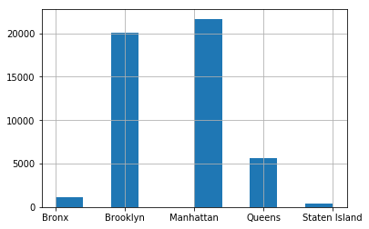

```python
df['neighbourhood_group'].hist()
plt.show()
```

```python
print("Percentage of Airbnbs in each neighbourhood in comparison to all of New York")
print(round(df['neighbourhood_group'].value_counts(normalize=True)*100, 3))
```

```
Percentage of Airbnbs in each neighbourhood in comparison to all of New York
Manhattan        44.301
Brooklyn         41.117
Queens           11.588
Bronx             2.231
Staten Island     0.763
Name: neighbourhood_group, dtype: float64
```

#### As shown here, Manhattan and Brooklyn are by far the most popular neighbourhood groups to host an Airbnb in NYC

### What neighborhood groups have the highest average Airbnb price?

```python
for area in df['neighbourhood_group'].unique():
    print(area + " " + str(df[df['neighbourhood_group'] == area]['price'].mean()) +" STD DEV: " + str(df[df['neighbourhood_group'] == area]['price'].std()))
```

```
Brooklyn 124.38320732192598 STD DEV: 186.87353781366113
Manhattan 196.8758136743456 STD DEV: 291.38318274158297
Queens 99.51764913519237 STD DEV: 167.10215506344343
Staten Island 114.81233243967829 STD DEV: 277.62040332462215
Bronx 87.4967919340055 STD DEV: 106.70934861314652
```

```
Neighbourhood: Brooklyn
```

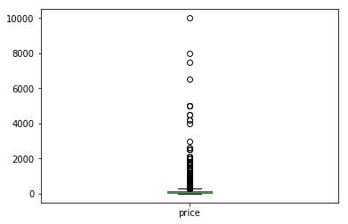

```
Neighbourhood: Manhattan
```

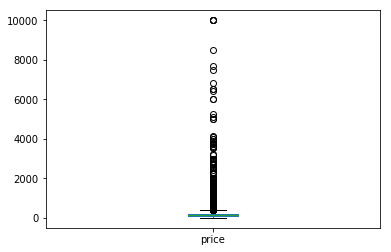

```
Neighbourhood: Queens
```

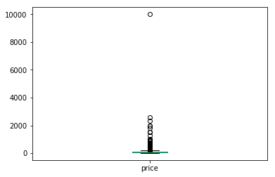

```
Neighbourhood: Staten Island
```

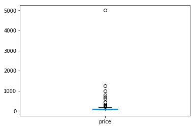

```
Neighbourhood: Bronx
```

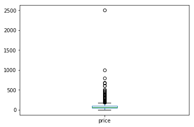

```python
for area in df['neighbourhood_group'].unique():
    print("Neighbourhood: " + area)
    df[df['neighbourhood_group'] == area]['price'].plot.box()
    plt.show()
```

```python
old_df = df
df = df[df['price'].between(df['price'].quantile(.15), df['price'].quantile(.85))] # without outliers
df
```

|  | id | name | host_id | host_name | neighbourhood_group | neighbourhood | latitude | longitude | room_type | price | minimum_nights | number_of_reviews | last_review | reviews_per_month | calculated_host_listings_count | availability_365 |
| --- | --- | --- | --- | --- | --- | --- | --- | --- | --- | --- | --- | --- | --- | --- | --- | --- |
| 14 | 6090 | West Village Nest - Superhost | 11975 | Alina | Manhattan | West Village | 40.73530 | -74.00525 | Entire home/apt | 120 | 90 | 27 | 2018-10-31 | 0.22 | 1 | 0 |
| 23 | 8110 | CBG Helps Haiti Rm #2 | 22486 | Lisel | Brooklyn | Park Slope | 40.68001 | -73.97865 | Private room | 110 | 2 | 71 | 2019-07-02 | 0.61 | 6 | 304 |
| 24 | 8490 | MAISON DES SIRENES1,bohemian apartment | 25183 | Nathalie | Brooklyn | Bedford-Stuyvesant | 40.68371 | -73.94028 | Entire home/apt | 120 | 2 | 88 | 2019-06-19 | 0.73 | 2 | 233 |
| 41 | 12299 | Beautiful Sunny Park Slope Brooklyn | 47610 | Abdul | Brooklyn | South Slope | 40.66278 | -73.97966 | Entire home/apt | 120 | 3 | 15 | 2019-05-27 | 0.39 | 1 | 345 |
| 42 | 12303 | 1bdr w private bath. in lofty apt | 47618 | Yolande | Brooklyn | Fort Greene | 40.69673 | -73.97584 | Private room | 120 | 7 | 25 | 2018-09-30 | 0.23 | 1 | 311 |
| 47 | 12940 | Charming Brownstone 3 - Near PRATT | 50148 | Adreinne | Brooklyn | Bedford-Stuyvesant | 40.68111 | -73.95591 | Entire home/apt | 110 | 7 | 61 | 2019-05-25 | 0.52 | 1 | 265 |
| 48 | 13050 | bright and stylish duplex | 50846 | Jennifer | Brooklyn | Bedford-Stuyvesant | 40.68554 | -73.94090 | Entire home/apt | 115 | 3 | 11 | 2017-01-01 | 0.10 | 1 | 0 |
| 56 | 14991 | Great Location, Manhattan Bedroom! | 59023 | Bianca | Manhattan | Lower East Side | 40.72004 | -73.99104 | Private room | 110 | 5 | 19 | 2019-05-18 | 0.17 | 1 | 301 |
| 74 | 17747 | BLUE TRIM GUEST HOUSE | 68599 | George | Brooklyn | Clinton Hill | 40.68346 | -73.96374 | Private room | 105 | 2 | 105 | 2019-06-26 | 0.92 | 1 | 304 |
| 81 | 19159 | Spacious luminous apt Upper West NYC | 73051 | Sybilla | Manhattan | Harlem | 40.82915 | -73.95136 | Entire home/apt | 110 | 31 | 54 | 2019-03-23 | 0.49 | 1 | 209 |
| 86 | 19812 | 2 bedroom Williamsburg Apt - Bedford L stop | 74857 | Starlee | Brooklyn | Williamsburg | 40.71833 | -73.95748 | Entire home/apt | 105 | 3 | 61 | 2018-08-09 | 0.53 | 1 | 272 |
| 94 | 20913 | Charming 1 bed GR8 WBurg LOCATION! | 79402 | Christiana | Brooklyn | Williamsburg | 40.70984 | -73.95775 | Entire home/apt | 100 | 5 | 168 | 2018-07-22 | 1.57 | 1 | 0 |
| 95 | 21293 | Sunny Apartment in Artist Home | 44145 | Tyrome | Brooklyn | Bushwick | 40.70093 | -73.92609 | Entire home/apt | 105 | 3 | 118 | 2019-06-18 | 1.05 | 2 | 9 |
| 104 | 24143 | Williamsburg—Steps To Subway, Private Bath&Bal... | 97219 | Seth | Brooklyn | Williamsburg | 40.71332 | -73.94177 | Private room | 101 | 3 | 335 | 2019-05-29 | 3.02 | 1 | 152 |
| 108 | 25696 | 1,800 sq foot in luxury building | 107628 | Dena | Manhattan | Harlem | 40.80920 | -73.94421 | Private room | 100 | 2 | 170 | 2019-06-23 | 1.61 | 1 | 346 |
| 113 | 26785 | Park Slope Green Guest House | 42273 | Dani | Brooklyn | South Slope | 40.66853 | -73.98912 | Entire home/apt | 120 | 30 | 467 | 2018-12-30 | 4.22 | 2 | 192 |
| 123 | 27883 | East Village Sanctuary | 120223 | Jen | Manhattan | East Village | 40.72245 | -73.98527 | Entire home/apt | 100 | 4 | 25 | 2011-12-10 | 0.23 | 1 | 0 |
| 129 | 29455 | ACCOMMODATIONS GALORE #1 | 126607 | Laurine | Manhattan | Harlem | 40.81618 | -73.94894 | Entire home/apt | 120 | 3 | 155 | 2019-06-20 | 1.42 | 3 | 213 |
| 133 | 30927 | Unique & Charming small 1br Apt. LES | 120335 | Cs | Manhattan | Lower East Side | 40.71341 | -73.98856 | Entire home/apt | 105 | 3 | 32 | 2019-06-14 | 0.29 | 1 | 16 |
| 135 | 31555 | Luminous Beautiful West Village Studio | 135619 | Tom | Manhattan | West Village | 40.73442 | -74.00303 | Entire home/apt | 115 | 29 | 26 | 2019-07-01 | 0.25 | 1 | 12 |
| 144 | 32965 | FLAT MACDONOUGH GARDEN | 137974 | Khem | Brooklyn | Bedford-Stuyvesant | 40.68281 | -73.93524 | Entire home/apt | 115 | 3 | 124 | 2019-06-20 | 1.72 | 2 | 170 |
| 153 | 36442 | Great location. Spacious on PROSPECT PARK | 137432 | Paz | Brooklyn | Prospect Heights | 40.67410 | -73.96595 | Entire home/apt | 115 | 15 | 4 | 2018-08-27 | 0.05 | 1 | 269 |
| 175 | 44229 | BROOKLYN VICTORIAN STYLE SUITE..... | 181376 | Carol | Brooklyn | Fort Greene | 40.69098 | -73.97113 | Private room | 110 | 2 | 213 | 2019-06-24 | 2.00 | 2 | 321 |
| 179 | 45542 | Clean and Cozy Harlem Apartment | 202249 | Campbell | Manhattan | Harlem | 40.82374 | -73.93730 | Entire home/apt | 100 | 2 | 18 | 2018-12-17 | 1.79 | 1 | 0 |
| 186 | 46911 | Large Room in private Brownstone in Park Slope | 210746 | Kathleen R. | Brooklyn | Prospect Heights | 40.67868 | -73.97307 | Private room | 120 | 3 | 51 | 2019-06-24 | 0.48 | 3 | 250 |
| 195 | 51572 | Prime Location in Manhattan | 237329 | Lee | Manhattan | Chelsea | 40.74859 | -73.99671 | Private room | 123 | 1 | 375 | 2019-06-18 | 3.52 | 1 | 328 |
| 203 | 54453 | MIDTOWN WEST - Large alcove studio | 255583 | Anka | Manhattan | Hell's Kitchen | 40.76548 | -73.98474 | Shared room | 105 | 6 | 10 | 2014-01-07 | 0.09 | 1 | 363 |
| 205 | 54508 | Sml Rm in pr Brst Park Sl great for Med/students | 210746 | Kathleen R. | Brooklyn | Prospect Heights | 40.67870 | -73.97262 | Private room | 100 | 2 | 226 | 2019-06-06 | 2.12 | 3 | 250 |
| 206 | 54544 | City Room - Private Penthouse Apt. | 256161 | Wayne | Manhattan | Harlem | 40.81035 | -73.94598 | Entire home/apt | 121 | 1 | 104 | 2019-06-22 | 1.00 | 5 | 247 |
| 208 | 54860 | Great apartment with private bathroom and entr... | 258164 | Jenny | Manhattan | East Harlem | 40.79958 | -73.94275 | Private room | 100 | 5 | 204 | 2019-06-23 | 1.92 | 1 | 192 |
| ... | ... | ... | ... | ... | ... | ... | ... | ... | ... | ... | ... | ... | ... | ... | ... | ... |
| 48600 | 36335028 | Quiet and safe neighborhood close to the bus | 235465195 | Monica | Queens | Flushing | 40.74761 | -73.81380 | Private room | 100 | 1 | 0 | NaN | NaN | 1 | 177 |
| 48603 | 36338430 | Zen Room in Creative Apt- <3 of Williamsburg | 10184022 | Elisa | Brooklyn | Williamsburg | 40.72078 | -73.95892 | Private room | 115 | 2 | 0 | NaN | NaN | 1 | 54 |
| 48634 | 36351128 | One bedroom without roomies, close to everything | 273361532 | David & Amy | Manhattan | Upper West Side | 40.80281 | -73.96550 | Entire home/apt | 110 | 3 | 2 | 2019-07-05 | 2.00 | 1 | 15 |
| 48648 | 36354796 | ✨Superb King Room , City View✨ | 273392981 | Giorgio Residence | Queens | Long Island City | 40.75716 | -73.94222 | Private room | 101 | 1 | 0 | NaN | NaN | 3 | 365 |
| 48653 | 36357112 | Sunny, adorable 1BR apartment in Greenpoint | 251802585 | Kay | Brooklyn | Greenpoint | 40.73192 | -73.95839 | Private room | 115 | 5 | 0 | NaN | NaN | 1 | 10 |
| 48657 | 36359394 | Madeline’s Place | 135363269 | Hal | Brooklyn | Sunset Park | 40.64372 | -74.00656 | Entire home/apt | 120 | 3 | 0 | NaN | NaN | 1 | 320 |
| 48663 | 36372104 | Exposed Brick | 32303395 | Roderick | Brooklyn | Bedford-Stuyvesant | 40.68580 | -73.92899 | Private room | 120 | 2 | 0 | NaN | NaN | 1 | 6 |
| 48664 | 36373544 | Large studio with tall ceiling near Central Park | 35141789 | Janey | Manhattan | Upper East Side | 40.78332 | -73.95155 | Entire home/apt | 100 | 10 | 0 | NaN | NaN | 1 | 21 |
| 48678 | 36381795 | Lovely one-bedroom;\nBrooklyn Heights | 289823 | Ben | Brooklyn | Brooklyn Heights | 40.69383 | -73.99328 | Entire home/apt | 115 | 14 | 0 | NaN | NaN | 1 | 17 |
| 48687 | 36384346 | ✨Superior King Room , Manhattan View✨ | 273392981 | Giorgio Residence | Queens | Long Island City | 40.75615 | -73.94121 | Private room | 101 | 1 | 0 | NaN | NaN | 3 | 365 |
| 48690 | 36384956 | Amazing True Loft/ Bed-Stuy/ Full Weekly Clean... | 2628658 | Marc-Antoine | Brooklyn | Bedford-Stuyvesant | 40.68194 | -73.93567 | Entire home/apt | 120 | 30 | 0 | NaN | NaN | 2 | 45 |
| 48696 | 36388492 | ✨Premier King Room , City View✨ | 273392981 | Giorgio Residence | Queens | Long Island City | 40.75559 | -73.94106 | Private room | 101 | 1 | 0 | NaN | NaN | 3 | 361 |
| 48702 | 36390301 | 3 Bedroom Apt in Ridgewood, 20 Min to Manhattan | 273632292 | Pete | Queens | Ridgewood | 40.70268 | -73.90353 | Entire home/apt | 110 | 24 | 0 | NaN | NaN | 1 | 183 |
| 48704 | 36391474 | Wonderful apartment close to Metro | 273025497 | Richard | Brooklyn | Fort Greene | 40.68868 | -73.97671 | Entire home/apt | 107 | 1 | 0 | NaN | NaN | 1 | 49 |
| 48731 | 36410519 | Sunlight charming apt. in the heart of Brooklyn | 121384174 | Luciana Paula | Brooklyn | Park Slope | 40.66716 | -73.98101 | Entire home/apt | 111 | 8 | 0 | NaN | NaN | 1 | 0 |
| 48736 | 36412880 | Massive Master Bedroom w Private Bathroom | 3427758 | Phil | Manhattan | Harlem | 40.81274 | -73.94357 | Private room | 110 | 3 | 0 | NaN | NaN | 1 | 199 |
| 48739 | 36413532 | Little hideaway at the East Village! | 48685332 | Carissa | Manhattan | East Village | 40.72146 | -73.98279 | Private room | 100 | 1 | 0 | NaN | NaN | 1 | 1 |
| 48764 | 36421786 | Luxury \| Private room \|Balcony\|Parking included | 211500809 | Stefania | Queens | Jackson Heights | 40.74765 | -73.89445 | Private room | 110 | 2 | 0 | NaN | NaN | 1 | 85 |
| 48765 | 36421796 | Cozy Room with Private Bathroom | 273843157 | Matheus | Brooklyn | Greenpoint | 40.73164 | -73.95187 | Private room | 105 | 1 | 0 | NaN | NaN | 1 | 199 |
| 48767 | 36422573 | Romantic studio in New York artistic best Bush... | 273849259 | Alexander | Brooklyn | Bushwick | 40.69958 | -73.92772 | Entire home/apt | 120 | 1 | 0 | NaN | NaN | 1 | 363 |
| 48775 | 36424465 | Private Room 10 mins away from Central Park | 157728550 | Kem | Manhattan | East Harlem | 40.80268 | -73.94244 | Private room | 100 | 1 | 0 | NaN | NaN | 2 | 343 |
| 48776 | 36424509 | Brooklyn Loft : Comfort & Sunset City Views | 8411075 | Ramiro | Brooklyn | Bushwick | 40.69608 | -73.91210 | Entire home/apt | 119 | 2 | 0 | NaN | NaN | 1 | 5 |
| 48805 | 36442252 | 1B-1B apartment near by Metro | 273841667 | Blaine | Bronx | Mott Haven | 40.80787 | -73.92400 | Entire home/apt | 100 | 1 | 2 | 2019-07-07 | 2.00 | 1 | 40 |
| 48807 | 36444457 | My Minimalist Sanctuary - Harlem Living | 19580888 | Lola | Manhattan | Harlem | 40.81589 | -73.95346 | Entire home/apt | 100 | 4 | 0 | NaN | NaN | 1 | 20 |
| 48816 | 36447054 | Entire first floor apartment in Park Slope | 71142174 | Toniann | Brooklyn | Sunset Park | 40.66266 | -73.98908 | Entire home/apt | 100 | 4 | 0 | NaN | NaN | 1 | 6 |
| 48818 | 36447795 | Beautiful studio Apt. in Harlem (near Red Roos... | 274035866 | Aurellia | Manhattan | East Harlem | 40.80780 | -73.93837 | Entire home/apt | 110 | 2 | 0 | NaN | NaN | 1 | 25 |
| 48861 | 36468409 | One bedroom Manhattan Upper East Side Apartment | 57502664 | Omar | Manhattan | Upper East Side | 40.76628 | -73.95795 | Entire home/apt | 120 | 1 | 0 | NaN | NaN | 1 | 1 |
| 48879 | 36480292 | Gorgeous 1.5 Bdr with a private yard- Williams... | 540335 | Lee | Brooklyn | Williamsburg | 40.71728 | -73.94394 | Entire home/apt | 120 | 20 | 0 | NaN | NaN | 1 | 22 |
| 48880 | 36481315 | The Raccoon Artist Studio in Williamsburg New ... | 208514239 | Melki | Brooklyn | Williamsburg | 40.71232 | -73.94220 | Entire home/apt | 120 | 1 | 0 | NaN | NaN | 3 | 365 |
| 48892 | 36485431 | Sunny Studio at Historical Neighborhood | 23492952 | Ilgar & Aysel | Manhattan | Harlem | 40.81475 | -73.94867 | Entire home/apt | 115 | 10 | 0 | NaN | NaN | 1 | 27 |

5784 rows × 16 columns

```
Neighbourhood: Manhattan
```

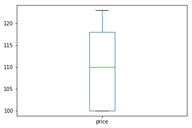

```
Neighbourhood: Brooklyn
```

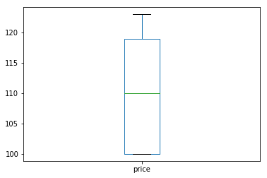

```
Neighbourhood: Bronx
```

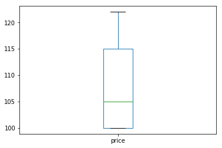

```
Neighbourhood: Queens
```

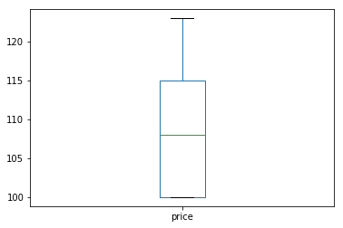

```
Neighbourhood: Staten Island
```

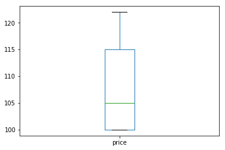

```python
for area in df['neighbourhood_group'].unique():
    print("Neighbourhood: " + area)
    df[df['neighbourhood_group'] == area]['price'].plot.box()
    plt.show()
```

#### On average, Manhattan and Brooklyn have the highest price per night as well as the most Airbnbs

#### Along with having the two highest average prices, Manhattan and Brooklyn are also by far the most popular locations to host an Airbnb

### Since Manhattan is so popular, let's look more into the smaller neighborhoods it contains

```python
Manh_neigh_price = list()
for area in df[df['neighbourhood_group'] == 'Manhattan']['neighbourhood'].unique():
    print(area + ": " + str(round(df[df['neighbourhood_group'] == 'Manhattan'][df['neighbourhood'] == area]['price'].mean(),2)))
    Manh_neigh_price.append((area, round(df[df['neighbourhood_group'] == 'Manhattan'][df['neighbourhood'] == area]['price'].mean(),2)))
```

```
West Village: 114.77
Lower East Side: 110.95
East Village: 111.36
Harlem: 110.04
Chelsea: 110.83
Hell's Kitchen: 111.73
Upper East Side: 112.87
Morningside Heights: 111.63
East Harlem: 109.3
NoHo: 112.2
Roosevelt Island: 107.27
Chinatown: 111.55
Midtown: 111.31
Upper West Side: 111.06
Two Bridges: 109.54
Kips Bay: 112.25
Murray Hill: 115.89
Washington Heights: 109.61
Financial District: 112.65
Greenwich Village: 112.56
Inwood: 107.22
Gramercy: 113.12
Nolita: 110.49
SoHo: 111.02
Tribeca: 107.21
Civic Center: 103.64
Theater District: 104.49
Battery Park City: 106.79
Flatiron District: 108.17
Little Italy: 111.37
Stuyvesant Town: 114.88
Marble Hill: 110.0
```

```python
Manh_neigh_price.sort(key = lambda x: x[1], reverse = True)
Manh_neigh_price[:5]
```

```
[('Murray Hill', 115.89),
 ('Stuyvesant Town', 114.88),
 ('West Village', 114.77),
 ('Gramercy', 113.12),
 ('Upper East Side', 112.87)]
```

#### Five most expensive areas in New York for Airbnbs

```python
NY_neigh_price = list()
for area in df['neighbourhood'].unique():
    print(area + ": " + str(round(df[df['neighbourhood'] == area]['price'].mean(),2)))
    NY_neigh_price.append((area, round(df[df['neighbourhood'] == area]['price'].mean(),2)))
```

```
West Village: 114.77
Crown Heights: 108.93
Park Slope: 112.22
Bedford-Stuyvesant: 110.86
South Slope: 111.47
Fort Greene: 113.29
Long Island City: 110.22
Lower East Side: 110.95
East Village: 111.36
Clinton Hill: 111.34
Harlem: 110.04
Flatbush: 108.52
Williamsburg: 109.69
Bushwick: 109.4
Chelsea: 110.83
Hell's Kitchen: 111.73
Prospect Heights: 113.08
Upper East Side: 112.87
Morningside Heights: 111.63
Middle Village: 106.91
East Harlem: 109.3
NoHo: 112.2
Roosevelt Island: 107.27
Chinatown: 111.55
Midtown: 111.31
Astoria: 109.44
Eastchester: 110.0
Upper West Side: 111.06
Greenpoint: 113.11
Brooklyn Heights: 114.31
Two Bridges: 109.54
Kips Bay: 112.25
Gowanus: 114.49
Forest Hills: 107.53
Murray Hill: 115.89
Boerum Hill: 115.23
Gravesend: 110.2
Allerton: 110.8
Fort Hamilton: 113.31
Bensonhurst: 112.05
```

[output cut: 137 more lines]

```
Melrose: 108.0
Mariners Harbor: 130.0
Little Neck: 100.0
Huguenot: 100.0
Rosebank: 100.0
Edgemere: 99.0
Schuylerville: 100.0
Unionport: 100.0
Soundview: 103.0
Jamaica Hills: 105.0
Morris Heights: 130.0
Parkchester: 100.0
Riverdale: 99.0
New Dorp Beach: 109.0
Castle Hill: 113.0
```

```python
NY_neigh_price.sort(key = lambda x: x[1], reverse = True)
NY_neigh_price[:5]
```

```
[('Mariners Harbor', 130.0),
 ('Morris Heights', 130.0),
 ('Navy Yard', 125.0),
 ('Norwood', 125.0),
 ('Olinville', 125.0)]
```

#### Before outliers are removed, Tribeca is the only neighourhood in Manhattan that is also in the top five most expensive Airbnbs in NYC. however none of the Manhattans neightborhoods were in the most expensive after removing outliers

### Now lets compare different types of room offerings

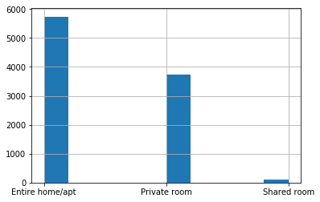

```python
df['room_type'].hist()
plt.show()
```

```python
for room_type in df['room_type'].unique():
    print(str(room_type) + " : " + str(round(df[df['room_type'] == room_type]['price'].mean(), 2)))
```

```
Entire home/apt : 112.75
Private room : 107.55
Shared room : 107.03
```

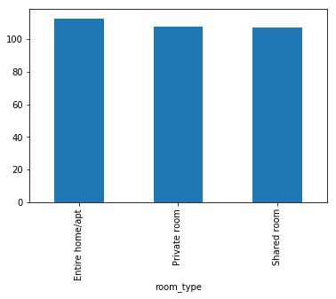

```python
df.groupby('room_type')['price'].mean().plot(kind='bar')
plt.show()
```

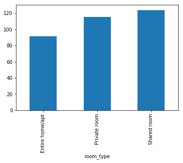

```python
df.groupby('room_type')['availability_365'].mean().plot(kind='bar')
plt.show()
```

#### From here you can see even though shared rooms are the cheapest with the most availability, other housing options are much more popular

### Which neighborhoods have the highest number of reviews per month?

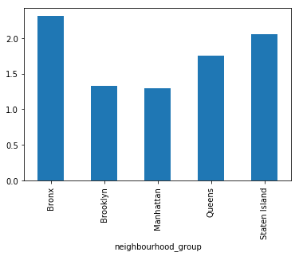

```python
df.groupby('neighbourhood_group')['reviews_per_month'].mean().plot(kind='bar')
plt.show()
```

#### Is there a correlation between price and number of reviews per month?

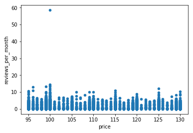

```python
df.plot.scatter(x='price', y='reviews_per_month')
plt.show()
```

```python
df.corr()
```

|  | id | host_id | latitude | longitude | price | minimum_nights | number_of_reviews | reviews_per_month | calculated_host_listings_count | availability_365 |
| --- | --- | --- | --- | --- | --- | --- | --- | --- | --- | --- |
| id | 1.000000 | 0.558945 | -0.010154 | 0.091848 | -0.022573 | -0.044170 | -0.320874 | 0.265794 | 0.059908 | 0.029297 |
| host_id | 0.558945 | 1.000000 | 0.025463 | 0.100563 | -0.026514 | -0.034691 | -0.130925 | 0.283307 | 0.113595 | 0.186013 |
| latitude | -0.010154 | 0.025463 | 1.000000 | 0.109417 | -0.010807 | 0.026473 | -0.022242 | -0.017836 | 0.012641 | -0.026946 |
| longitude | 0.091848 | 0.100563 | 0.109417 | 1.000000 | -0.060758 | -0.050174 | 0.033915 | 0.120831 | -0.079976 | 0.108447 |
| price | -0.022573 | -0.026514 | -0.010807 | -0.060758 | 1.000000 | 0.021369 | -0.011382 | -0.044635 | 0.040925 | 0.011734 |
| minimum_nights | -0.044170 | -0.034691 | 0.026473 | -0.050174 | 0.021369 | 1.000000 | -0.056451 | -0.110840 | 0.096516 | 0.133013 |
| number_of_reviews | -0.320874 | -0.130925 | -0.022242 | 0.033915 | -0.011382 | -0.056451 | 1.000000 | 0.548388 | -0.050704 | 0.216520 |
| reviews_per_month | 0.265794 | 0.283307 | -0.017836 | 0.120831 | -0.044635 | -0.110840 | 0.548388 | 1.000000 | -0.056028 | 0.198984 |
| calculated_host_listings_count | 0.059908 | 0.113595 | 0.012641 | -0.079976 | 0.040925 | 0.096516 | -0.050704 | -0.056028 | 1.000000 | 0.196405 |
| availability_365 | 0.029297 | 0.186013 | -0.026946 | 0.108447 | 0.011734 | 0.133013 | 0.216520 | 0.198984 | 0.196405 | 1.000000 |

#### From here, you can see price and number of reviews per month have nearly no correlation(-0.044635)

#### And from this matrix of correlations shows that price does not correlate with anything else in the dataset. It could correlate with things like reviews, but those are not provided.

### How does the number of listings each host has correspond to the neighourhood

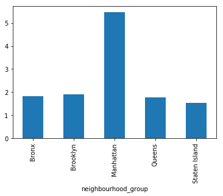

```python
df.groupby('neighbourhood_group')['calculated_host_listings_count'].mean().plot(kind='bar')
plt.show()
```

### What is the largest amount of rentals that a single host has?

```python
host_listings = list()
for host_id in df['host_id'].unique():
    host_listings.append((str(host_id), len(df[df['host_id'] == host_id])))
host_listings.sort(key = lambda x: x[1], reverse = True)
host_listings[:5]
```

```
[('13347167', 21),
 ('1475015', 16),
 ('213781715', 16),
 ('219517861', 14),
 ('260639745', 13)]
```

## Data shortcomings

#### Data set did not include ratings of individual rentals or hosts, only number of ratings.

#### No seasonal data provided, so could not see when the best time to visit NYC is

### References:

https://nextjournal.com/schmudde/how-to-remove-outliers-in-data